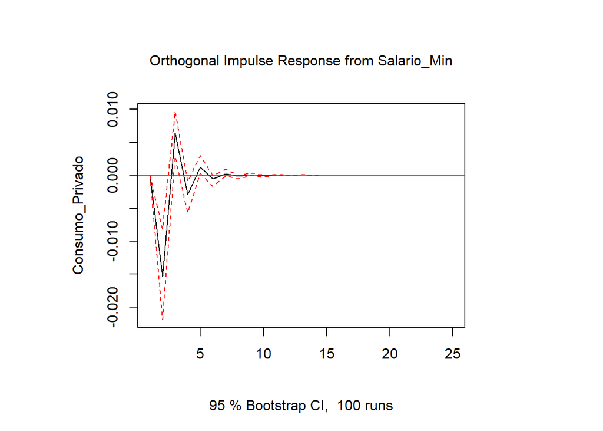

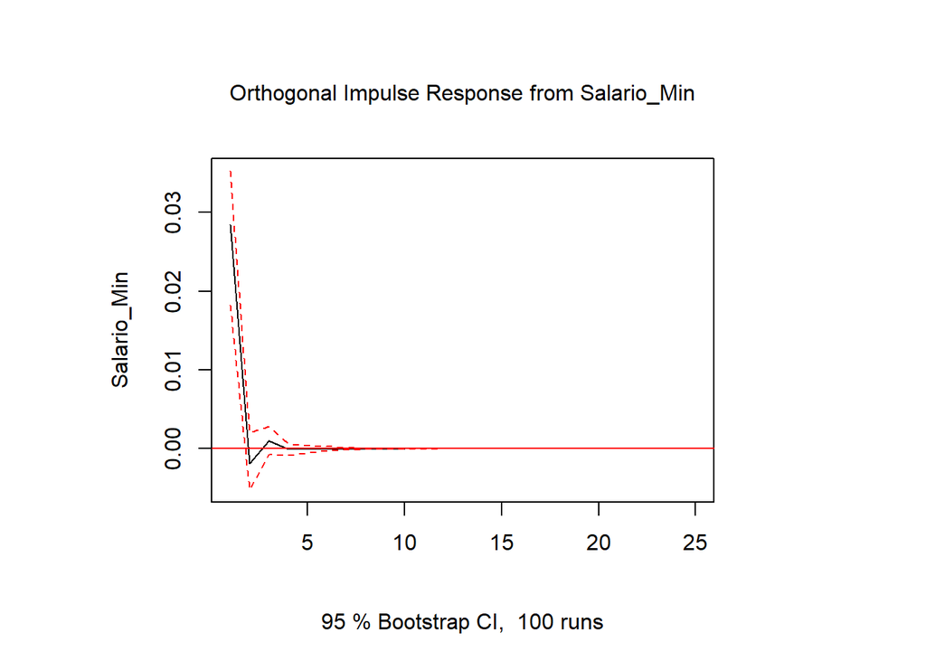

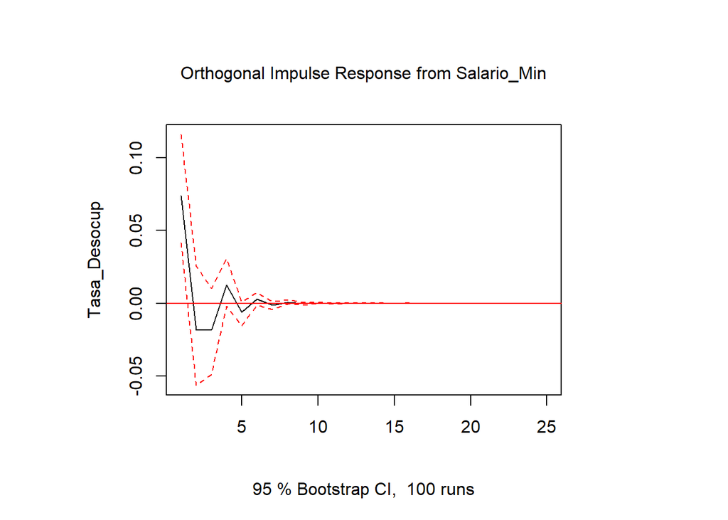

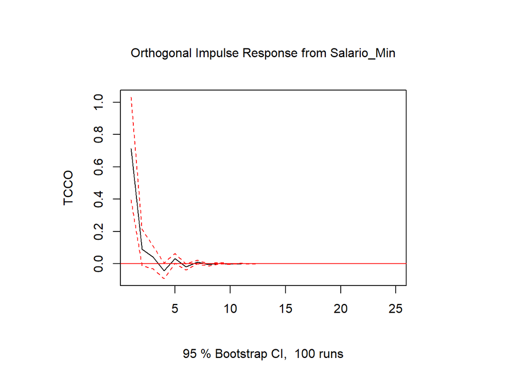

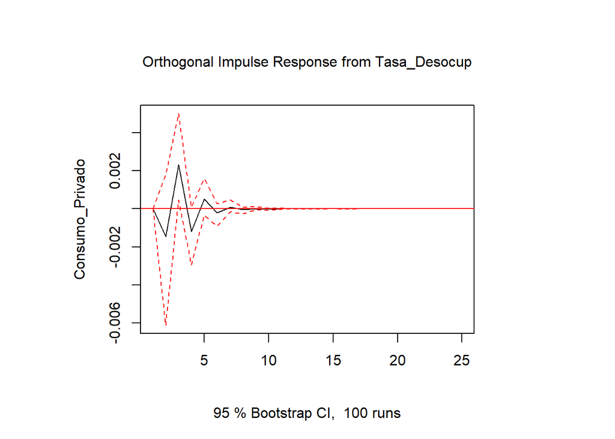

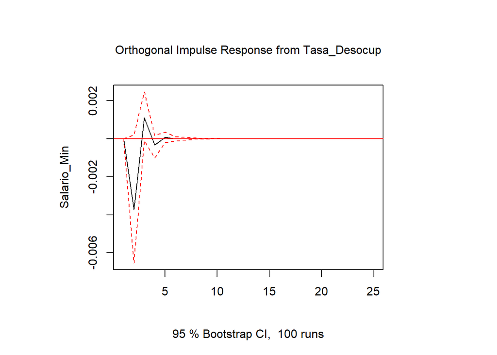

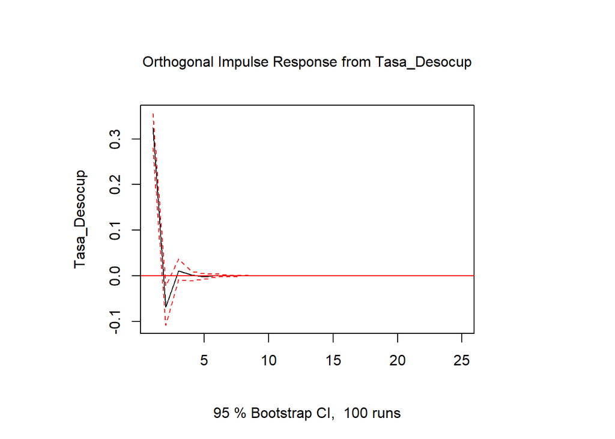

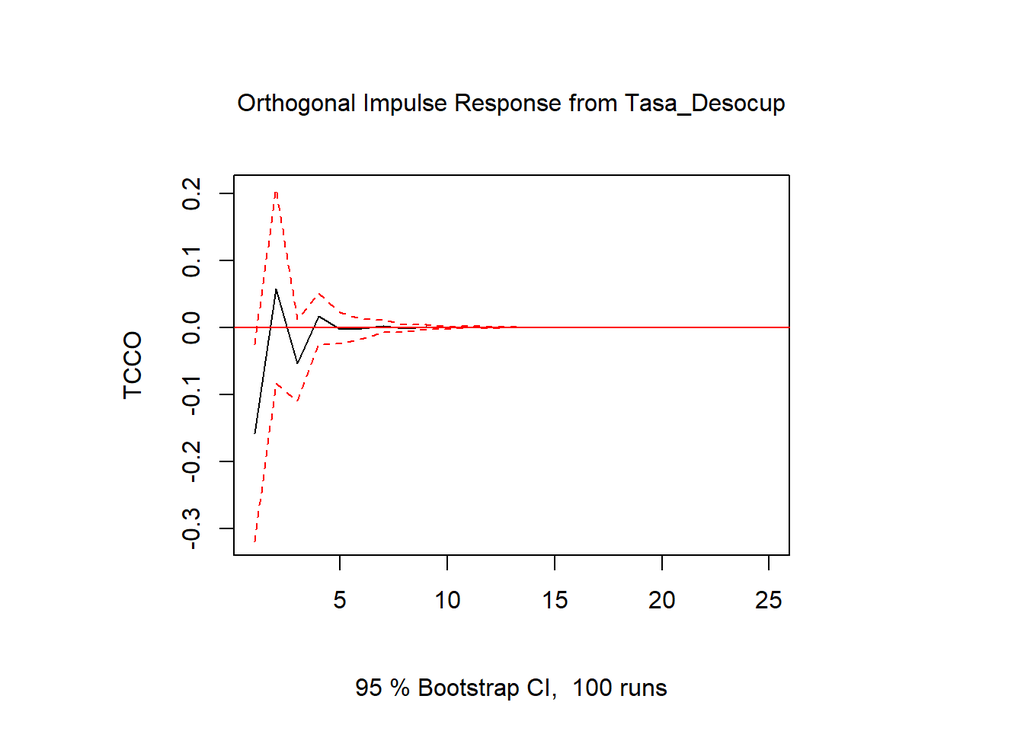

[4 more figures not shown]

Se estimaron funciones impulso–respuesta (IRF) para analizar la dinámica de corto plazo entre las variables seleccionadas. En general, las respuestas obtenidas fueron estables y convergentes, lo que confirma la validez del VAR(1).

```r
# FEVD a 24 periodos
fevd_var4 <- fevd(var4, n.ahead = 24)

# VResultados de cada ecuación
fevd_var4
```

[output not shown]

La descomposición de varianza del modelo VAR(1) muestra el grado en que los errores de pronóstico de cada variable son explicados por shocks propios y por innovaciones provenientes del resto del sistema. Los resultados indican que:

- Consumo Privado es altamente inercial: aproximadamente 80 % de su variabilidad futura proviene de sí mismo. El Salario Mínimo explica cerca del 18 %, mientras que la Tasa de Desocupación y el TCCO aportan menos del 2 %. Esto indica que el consumo responde principalmente a sus propios ciclos, con una influencia secundaria del salario.
- Salario Mínimo es la variable más autónoma del sistema, con más del 92 % de su variabilidad explicada por shocks propios. El Consumo Privado explica cerca del 5 %, mientras que el resto de las variables tienen efectos marginales. Esto sugiere una dinámica casi independiente dentro del sistema.
- Tasa de Desocupación muestra una fuerte sensibilidad a las demás variables: aunque alrededor del 73 % se explica por sí misma, cerca del 23 % proviene del Consumo Privado, y alrededor del 4 % del Salario Mínimo. Esto confirma que la actividad económica y el mercado laboral están fuertemente interconectados.
- TCCO es la variable más influenciada por el sistema: alrededor del 53 % se explica por shocks propios, mientras que el Salario Mínimo aporta cerca del 35 %, el Consumo Privado alrededor del 10 %, y la Tasa de Desocupación cerca del 2 %. Esto implica que TCCO responde de forma notable a la política salarial y a las condiciones económicas generales.

En conjunto, los resultados del FEVD muestran que Consumo Privado y Salario Mínimo son relativamente exógenos, mientras que Tasa de Desocupación y TCCO son claramente endógenos, confirmando la estructura dinámica detectada en los IRFs y fortaleciendo la validez del modelo VAR estimado.

## Proyección

### Pronóstico para Consumo_Privado

Pronóstico para Consumo_Privado

| Forecast | Lower | Upper |
| --- | --- | --- |
| 0.0007 | -0.0663 | 0.0678 |
| 0.0034 | -0.0721 | 0.0789 |
| 0.0008 | -0.0763 | 0.0779 |
| 0.0022 | -0.0752 | 0.0796 |
| 0.0015 | -0.0759 | 0.0790 |
| 0.0018 | -0.0756 | 0.0793 |

### Pronóstico para Salario_Min

Pronóstico para Salario_Min

| Forecast | Lower | Upper |
| --- | --- | --- |
| 0.0023 | -0.0551 | 0.0596 |
| 0.0042 | -0.0538 | 0.0622 |
| 0.0037 | -0.0544 | 0.0617 |
| 0.0038 | -0.0543 | 0.0619 |
| 0.0038 | -0.0543 | 0.0619 |
| 0.0038 | -0.0543 | 0.0619 |

### Pronóstico para Tasa_Desocup

Pronóstico para Tasa_Desocup

| Forecast | Lower | Upper |
| --- | --- | --- |
| -0.0357 | -0.7633 | 0.6918 |
| 0.0025 | -0.7564 | 0.7614 |
| -0.0030 | -0.7649 | 0.7589 |
| -0.0051 | -0.7676 | 0.7574 |
| -0.0030 | -0.7656 | 0.7597 |
| -0.0042 | -0.7669 | 0.7585 |

### Pronóstico para TCCO

Pronóstico para TCCO

| Forecast | Lower | Upper |
| --- | --- | --- |
| -0.0296 | -2.2719 | 2.2128 |
| 0.0933 | -2.2544 | 2.4409 |
| 0.0581 | -2.3183 | 2.4346 |
| 0.0800 | -2.3048 | 2.4648 |
| 0.0658 | -2.3215 | 2.4531 |
| 0.0746 | -2.3134 | 2.4626 |

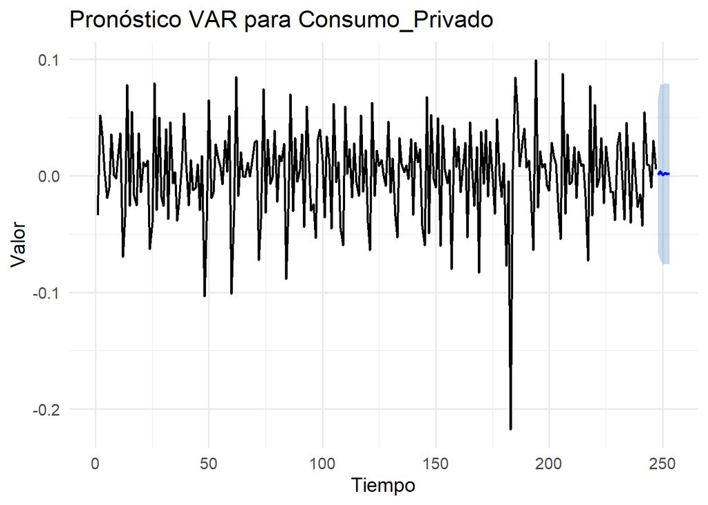

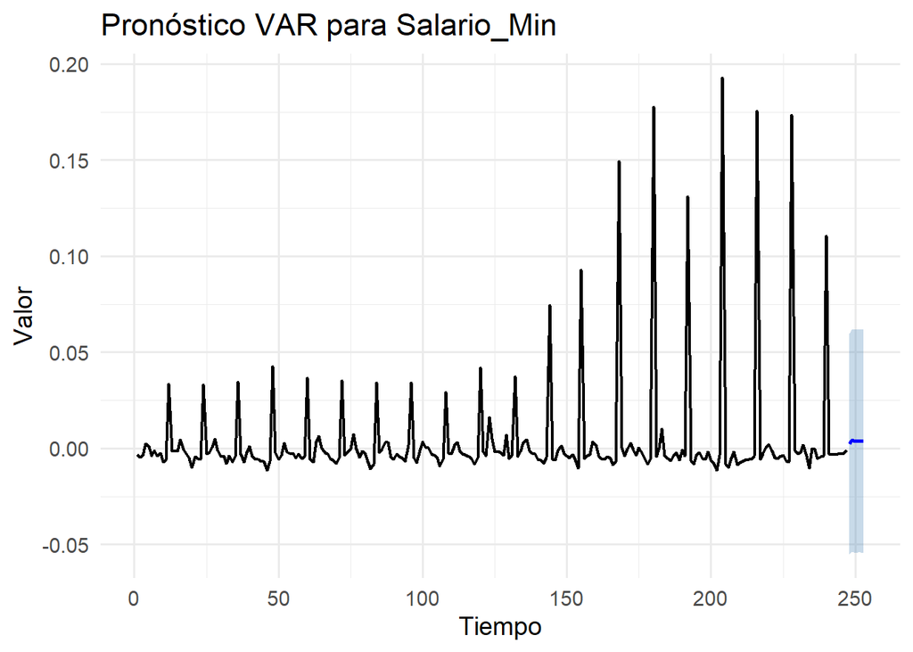

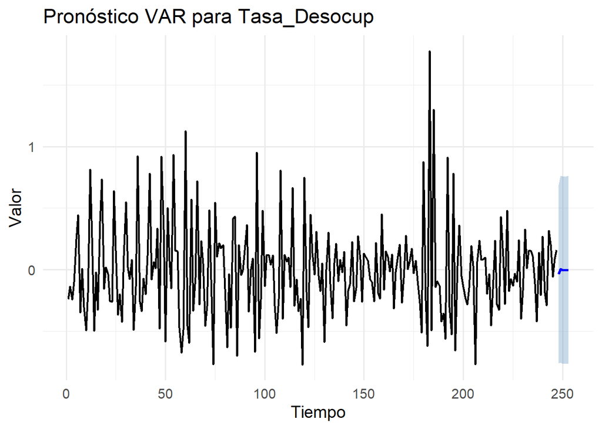

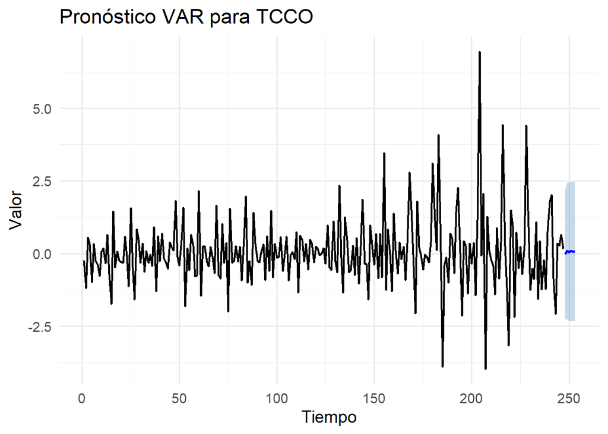

Consumo Privado: El pronóstico se mantiene prácticamente estable (en torno a 0.0017), lo que sugiere un crecimiento marginal y sostenido. Los intervalos de confianza son moderadamente estrechos, indicando una incertidumbre baja y una dinámica relativamente predecible dentro del sistema.

Salario Mínimo: Presenta incrementos pequeños y constantes (≈0.0038). El modelo anticipa un comportamiento suave sin shocks relevantes. Los intervalos de confianza son reducidos, reflejando estabilidad y una trayectoria relativamente inercial.

TCCO: Muestra incrementos leves (≈0.07), pero sus intervalos de confianza son los mayores del modelo (aprox. ±2.39). Esto confirma que la TCCO es la variable con mayor variabilidad e impacto acumulado dentro del sistema dinámico.

En general, el VAR(1) pronostica dinámicas suaves y relativamente estables en las variables reales (Consumo Privado y Salario Mínimo), mientras que las variables financieras (Tasa de Desocupación y TCCO) presentan mayor incertidumbre, lo cual es consistente con su variabilidad histórica.

## Mapa de flujo de decisiones

[interactive chart not shown]

El diagrama de flujo representa todas las etapas involucradas en el proceso de construcción, validación y utilización del modelo econométrico construido. El propósito es mostrar, de manera estructurada, cómo fueron las tomas de decisiones desde la preparación de los datos hasta la generación de pronósticos.

1. Inicio y análisis de datos:

El proceso comenzó con la recopilación del conjunto de datos obtenidos de las plataformas oficiales del INEGI, BANXICO y CONASAMI. Para posteriormente realizar un análisis exploratorio que incluyó:

- Gráficos de las series
- Medidas descriptivas
- Revisión de tendencias, estacionalidad y patrones estructurales
2. Transformaciones necesarias

Se realizaron tranformaciones a las series originales, puesto que las series originales no eran estacionarias. Lo que se realizó fue lo siguiente:

- Logaritmos
- Diferencias
- Gráficas

Estas transformaciones aseguran que las series cumplan los requisitos del modelo o que sean coherentes con su interpretación económica.

3. Evaluación de estacionariedad

A partir de las series modificadas se aplican pruebas estadísticas como:

- ADF (Augmented Dickey–Fuller)
- KPSS (Kwiatkowski–Phillips–Schmidt–Shin)

Estas pruebas permiten determinar si las series son estacionarias. Además de graficar los ACFs y los PACFs.

4. Selección preliminar del modelo

Una vez que las series estuvieron listas, se analizó qué tipo de modelo podría utilizarse:

- Se evaluaron rezagos óptimos
- Se revisaron criterios de información (AIC, BIC, HQ)
- Y se examinó la estructura de interdependencia entre variables
5. Pruebas de cointegración

Con las series ya preparadas, se aplicó la prueba de Johansen para verificar si existe cointegración entre las variables:

- Si *sí* hay cointegración → el modelo adecuado es *VEC*
- Si *no* hay cointegración → se utiliza un *VAR*
6. Estimación del modelo

Se obtuvieron parámetros tanto del VEC y el VAR.

7. Diagnósticos del modelo

Una vez que se estimó el modelo, se sometió a pruebas para validar su confiabilidad:

- Autocorrelación de residuales
- Normalidad
- Heterocedasticidad
- Estabilidad del sistema
- Raíces características
8. Validación del modelo

Si el modelo cumplió con todos los diagnósticos estadísticos, se considera *válido* para su uso.

9. Análisis dinámico

Con el modelo ya validado se realizó un análisis estructural:

- IRF (Funciones Impulso-Respuesta)
- FEVD (Descomposición de la varianza del error de pronóstico)

Estas herramientas permiten interpretar cómo los choques afectan cada variable y cuál es la importancia relativa de los shocks dentro del sistema.

10. Proyecciones o pronósticos

Finalmente, el modelo se utiliza para generar:

- Pronósticos de corto plazo (6 meses)
- Intervalos de confianza
- Y gráficos comparativos entre datos históricos y predicciones
11. Fin del proceso

El flujo concluye luego de la generación de pronósticos.

## Conclusiones

El análisis econométrico realizado para este proyecto, permitió evaluar de forma integral las dinámicas de la demanda interna en México a partir de variables macroeconómicas clave. Los resultados ofrecieron evidencia útil para validar parcialmente la hipótesis planteada, así como para identificar las interrelaciones económicas más relevantes entre consumo privado, condiciones laborales, salarios y condiciones financieras.

- **Validación o rechazo de la hipótesis**

  La hipótesis del proyecto establecía que:

  *“Las variaciones en la inflación (INPC), la actividad económica (IGAE), la tasa de interés (TIIE a 28 días), los salarios mínimos, el tipo de cambio y el nivel de desocupación influyen de manera significativa en el comportamiento del consumo privado en México.”*

  Con base en los resultados obtenidos, se confirmó la existencia de relaciones dinámicas a corto plazo entre el consumo privado y variables como los salarios, la tasa de desocupación y la TCCO, a través del análisis IRF y FEVD. Además, la cointegración detectada entre varias variables sugiere la presencia de relaciones de largo plazo. Sin embargo, los modelos VECM estimados fueron inestables, lo que impidió que se utilizara como un modelo final. Por lo cual, el modelo utilizado fue un VAR(1) en primeras diferencias, estable y válido para análisis de corto plazo, aunque limitado para evaluar relaciones de equilibrio de largo plazo.

  Por lo anterior, se podría decir que la hipótesis es válida, pero parcialmente.
- **Impacto económico, social o actuarial del estudio**

  Los resultados obtenidos permiten realizar un análisis de diferentes aspectos de relevancia. Para empezar, en el ámbito económico, el consumo privado muestra una dinámica suave y marginal, consistente con la debilidad estructural de la economía mexicana. La Tasa de Desocupación y la TCCO presentan alta volatilidad, lo que indica vulnerabilidad en el mercado laboral.

  En el ámbito social, el aumento del empleo informal y el estancamiento del empleo formal reflejan tensiones sociales y falta de resiliencia laboral. Además, una demanda interna débil afecta directamente el bienestar de los hogares, reduciendo su capacidad de consumo y su estabilidad financiera.

  Por último, desde un punto actuarial, se puede analizar que la alta volatilidad de la Tasa de Condiciones Críticas de Ocupación (TCCO) y de la tasa de desocupación implica mayor incertidumbre en la estimación de riesgos laborales y financieros.Y, la estabilidad relativa de las variables reales (consumo y salarios) sugiere que los modelos actuariales que dependen de estas series pueden realizar proyecciones más confiables a corto plazo.

En general, este estudio evidencia que la economía mexicana enfrenta una demanda interna débil, marcada por un consumo que apenas crece, un mercado laboral frágil y condiciones financieras volátiles. El modelo VAR(1) permitó capturar las relaciones dinámicas de corto plazo entre las variables seleccionadas y generar pronósticos que reflejan estabilidad moderada, pero también incertidumbre significativa en los componentes laborales y financieros.

Aunque las restricciones del modelo impidieron validar las relaciones de largo plazo, los resultados obtenidos son suficientes para señalar que el fortalecimiento del mercado interno requiere políticas económicas integrales enfocadas en empleo formal, estabilidad salarial y condiciones financieras que impulsen el consumo y la inversión.

## Bibliografía

Portal de Finanzas Públicas de la Cámara de Diputados. (2020, 14 abril). CEFP - Análisis En Finanzas Públicas. https://www.cefp.gob.mx/

S&P Global Ratings. (n.d.). https://www.spglobal.com/ratings/es/regulatory/delegate/getPDF?articleId=3481529&type=COMMENTS&defaultFormat=PDF

México: panorama general. (n.d.). World Bank. https://www.bancomundial.org/es/country/mexico/overview

Urrutia, A. R. (2025, June 6). Economía mexicana: persiste la debilidad. Revista IMEF. https://www.revista.imef.org.mx/articulo/economia-mexicana-persiste-la-debilidad/

Salazar, S. A. (2025, October 16). México | El gasto privado pierde dinamismo en septiembre con deterioro de expectativas. BBVA Research. https://www.bbvaresearch.com/publicaciones/mexico-el-gasto-privado-pierde-dinamismo-en-septiembre-con-deterioro-de-expectativas/